# Einfache Graphiken

Jan-Philipp Kolb

12 Juni 2017

# Ein Plot sagt mehr als 1000 Worte

- Grafisch gestÃ¼tzte Datenanalyse ist toll
- Gute Plots können zu einem besseren Verständnis beitragen
- Einen Plot zu generieren geht schnell
- Einen guten Plot zu machen kann sehr lange dauern
- Mit R Plots zu generieren macht SpaÃŸ
- Mit R erstellte Plots haben hohe QualitÃ¤t
- Fast jeder Plottyp wird von R unterstÃ¼tzt
- R kennt eine große Menge an Exportformaten für Grafiken

# Plot ist nicht gleich Plot

- Bereits das base Package bringt eine groÃŸe Menge von Plot Funktionen mit
- Das lattice Packet erweitert dessen FunktionalitÃ¤t
- Eine weit über diese Einführung hinausgehende Übersicht findet sich in Murrell, P (2006): R Graphics.

# Task View zu Thema [Graphiken](https://cran.r-project.org/web/views/Graphics.html)

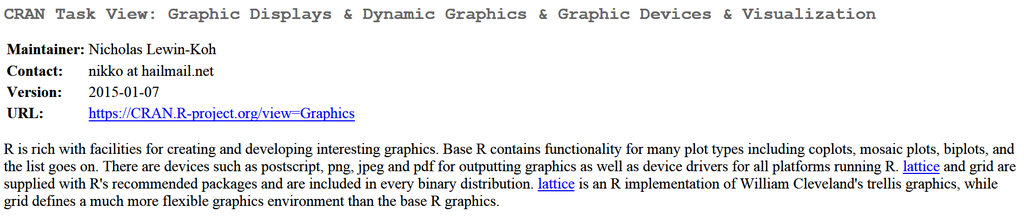

# Datensatz

```r
library(mlmRev)
data(Chem97)
```

- [lea] Local Education Authority - a factor
- [school] School identifier - a factor
- [student] Student identifier - a factor
- [score] Point score on A-level Chemistry in 1997
- [gender] Student’s gender
- [age] Age in month, centred at 222 months or 18.5 years
- [gcsescore] Average GCSE score of individual.
- [gcsecnt] Average GCSE score of individual, centered at mean.

# Histogramm - Die Funktion hist()

Wir erstellen ein Histogramm der Variable gcsescore:

```r
?hist
```

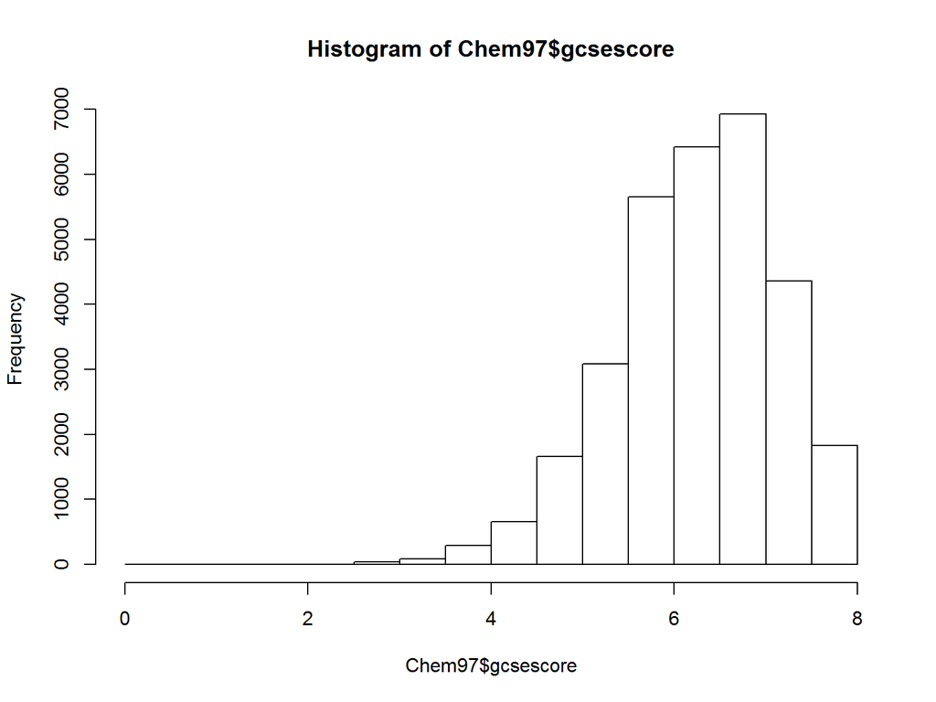

```r
hist(Chem97$gcsescore)
```

# Graphik speichern

- Mit dem button Export in Rstudio kann man die Grafik speichern.

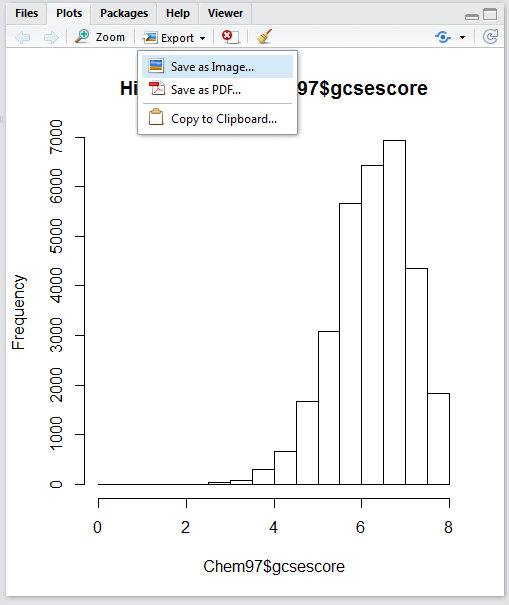

# Befehl um Graphik zu speichern

- Alternativ auch bspw. mit den Befehlen `png`, `pdf` oder `jpeg`

```r
png("Histogramm.png")
hist(Chem97$gcsescore)
dev.off()
```

# Histogramme

- Die Funktion `hist()` plottet ein Histogramm der Daten
- Der Funktion muss mindestens ein Beobachtungsvektor Ã¼bergeben werden
- `hist()` hat noch sehr viel mehr Argumente, die alle (sinnvolle) default values haben

| Argument | Bedeutung | Beispiel |
| --- | --- | --- |
| main | Ãœberschrift | main=“Hallo Welt” |
| xlab | x-Achsenbeschriftung | xlab=“x-Werte” |
| ylab | y-Achsenbeschriftung | ylab=“y-Werte” |
| col | Farbe | col=“blue” |

# Histogramm

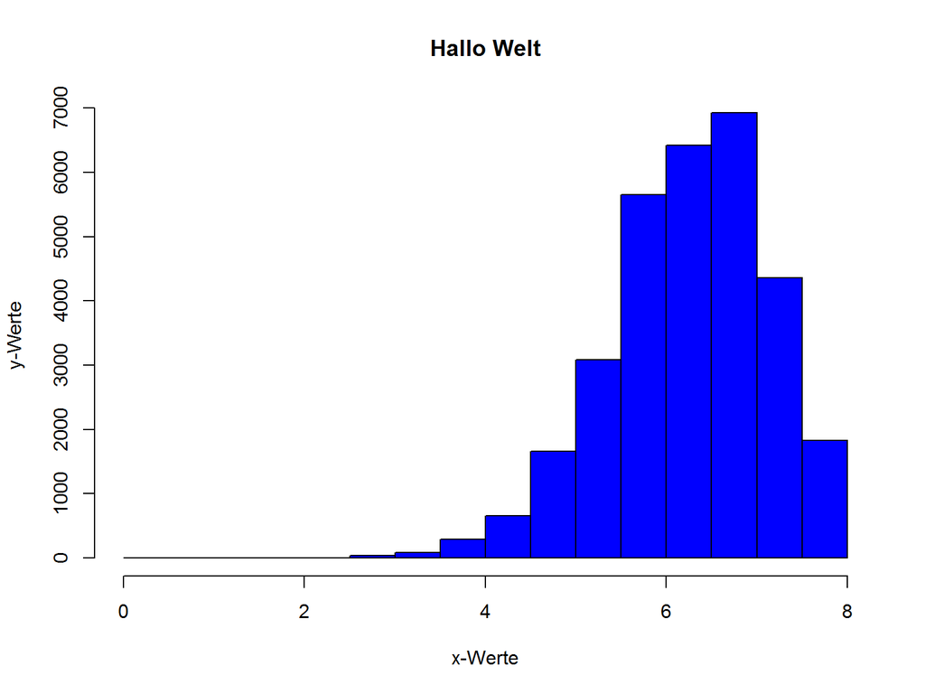

```r
hist(Chem97$gcsescore,col="blue",
     main="Hallo Welt",ylab="y-Werte", xlab="x-Werte")
```

Weitere Argumente:

```r
?plot
# oder
?par
```

# Barplot

- Die Funktion `barplot()` erzeugt aus einer HÃ¤ufigkeitstabelle einen Barplot
- Ist das Ã¼bergebene Tabellen-Objekt zweidimensional wird ein bedingter Barplot erstellt

```r
tabScore <- table(Chem97$score)
```

```r
barplot(tabScore)
```

# Barplots und barcharts

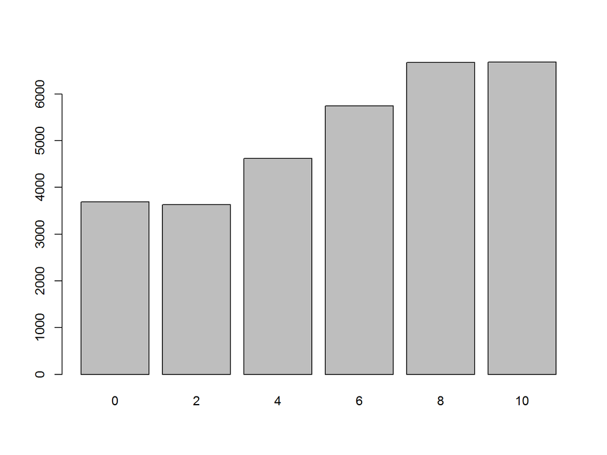

```r
barplot(tabScore)
```

# Mehr Farben:

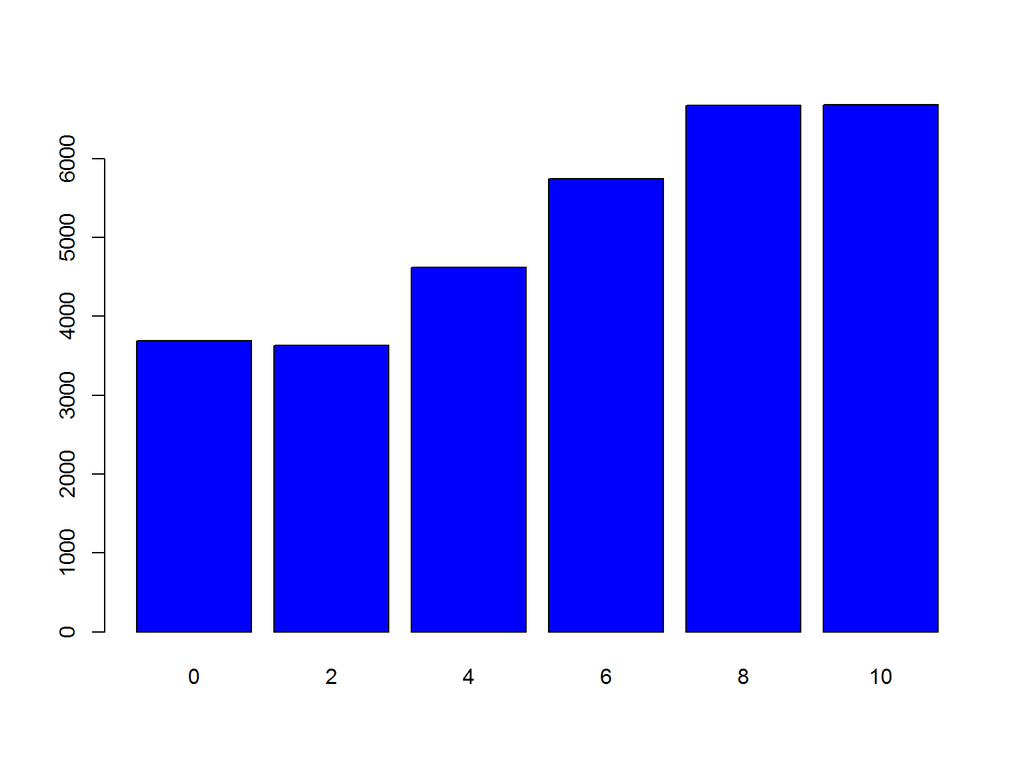

```r
barplot(tabScore,col=rgb(0,0,1))
```

# GrÃ¼ne Farbe

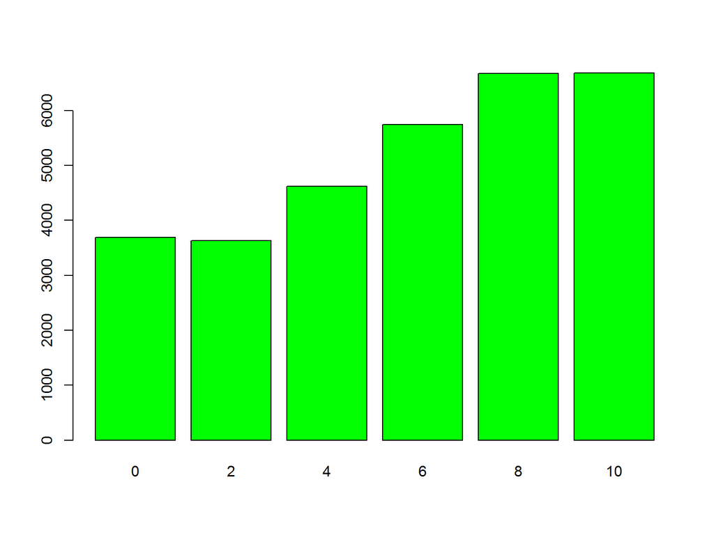

```r
barplot(tabScore,col=rgb(0,1,0))
```

# Rote Farbe

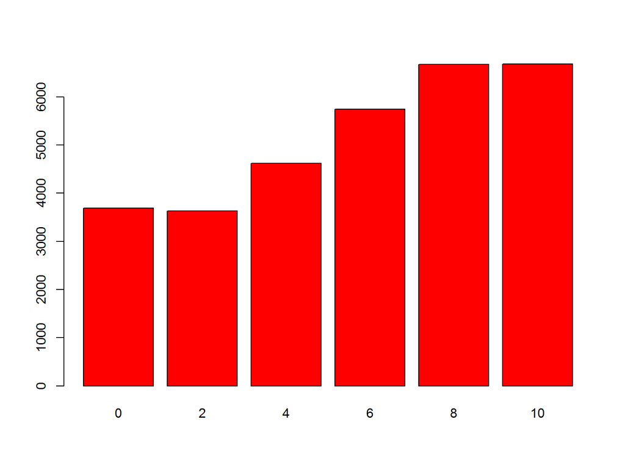

```r
barplot(tabScore,col=rgb(1,0,0))
```

# Transparent

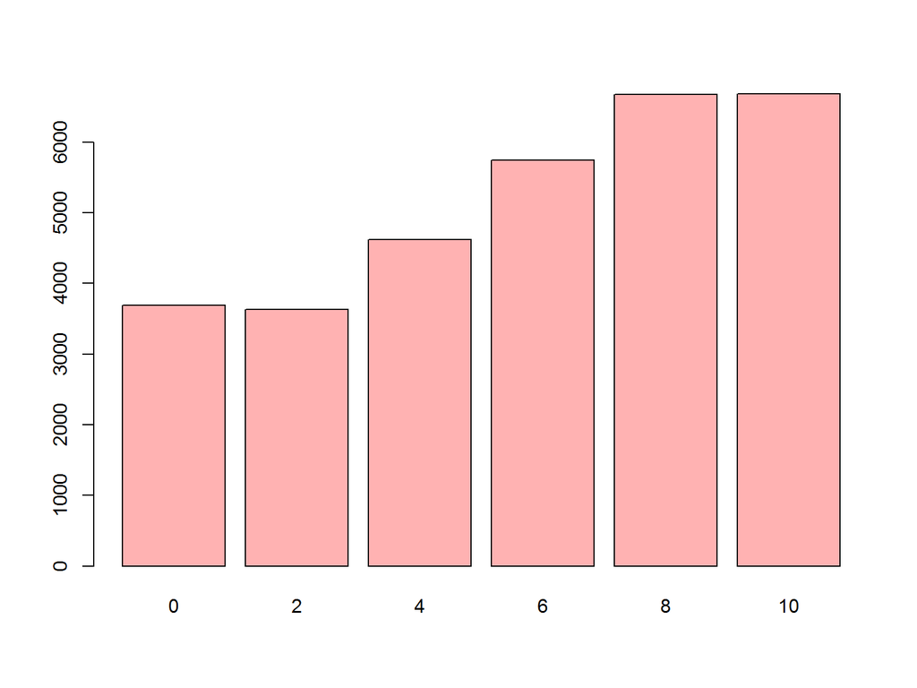

```r
barplot(tabScore,col=rgb(1,0,0,.3))
```

# Boxplot

- Einen einfachen Boxplot erstellt man mit `boxplot()`
- Auch `boxplot()` muss mindestens ein Beobachtungsvektor Ã¼bergeben werden

```r
?boxplot
```

# Horizontaler Boxplot

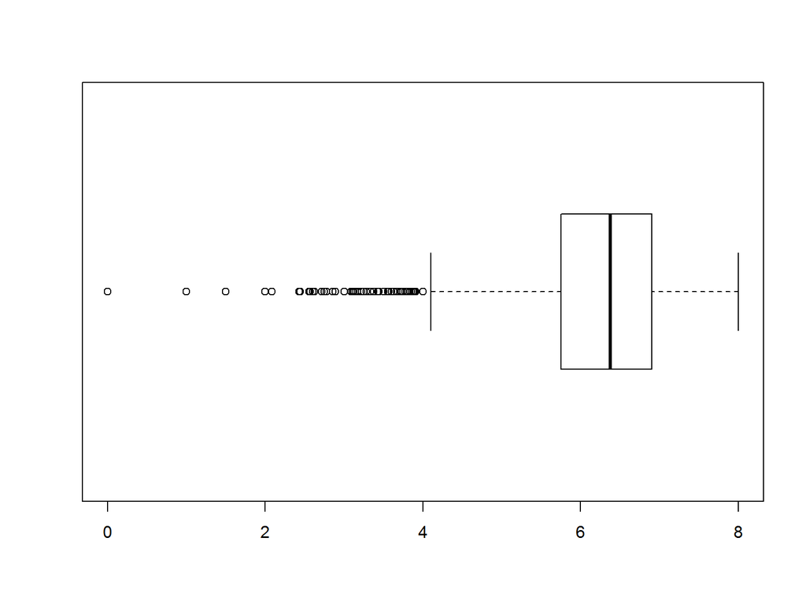

```r
boxplot(Chem97$gcsescore,
horizontal=TRUE)
```

- [ErklÃ¤rung zu Boxplots](http://edoc.hu-berlin.de/dissertationen/gruenwald-andreas-2005-01-17/HTML/chapter2.html)

# Gruppierte Boxplots

# Beispiel grupierter Boxplot

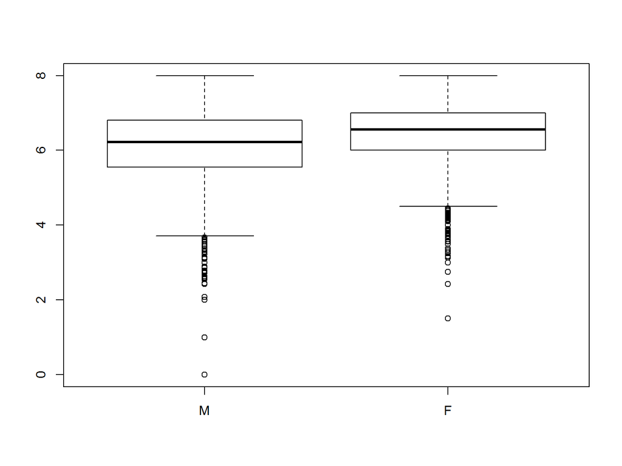

```r
boxplot(Chem97$gcsescore~Chem97$gender)
```

# Alternativen zu Boxplot

Violinplot

- Baut auf Boxplot auf
- Zusätzlich Informationen über Dichte der Daten
- Dichte wird Ã¼ber Kernel Methode berechnet.
- weiÃŸer Punkt - Median
- Je weiter die Ausdehnung, desto größer ist die Dichte an dieser Stelle.

```r
# Beispieldaten erzeugen
x <- rnorm(100)
y <- rnorm(100)
```

# Die Bibliothek `vioplot`

```r
library(vioplot)
plot(x, y, xlim=c(-5,5), ylim=c(-5,5))
vioplot(x, col="tomato", horizontal=TRUE, at=-4,
        add=TRUE,lty=2, rectCol="gray")
vioplot(y, col="cyan", horizontal=FALSE, at=-4,
        add=TRUE,lty=2)
```

# `vioplot` - Das Ergebnis

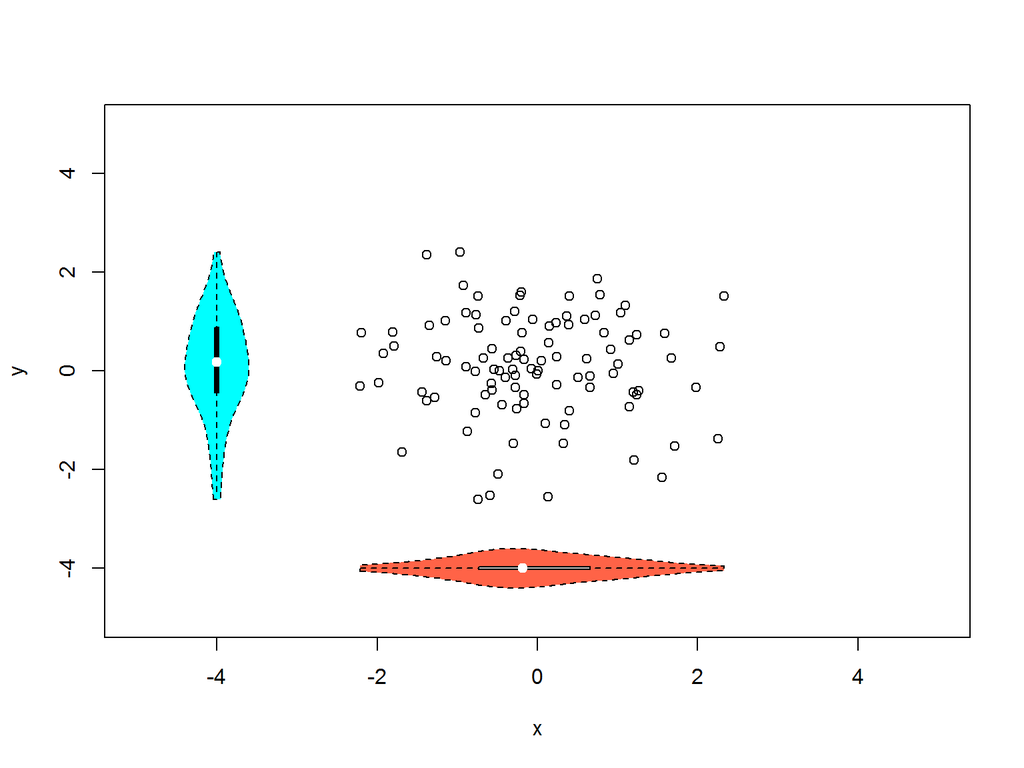

# Alternativen zum Boxplot

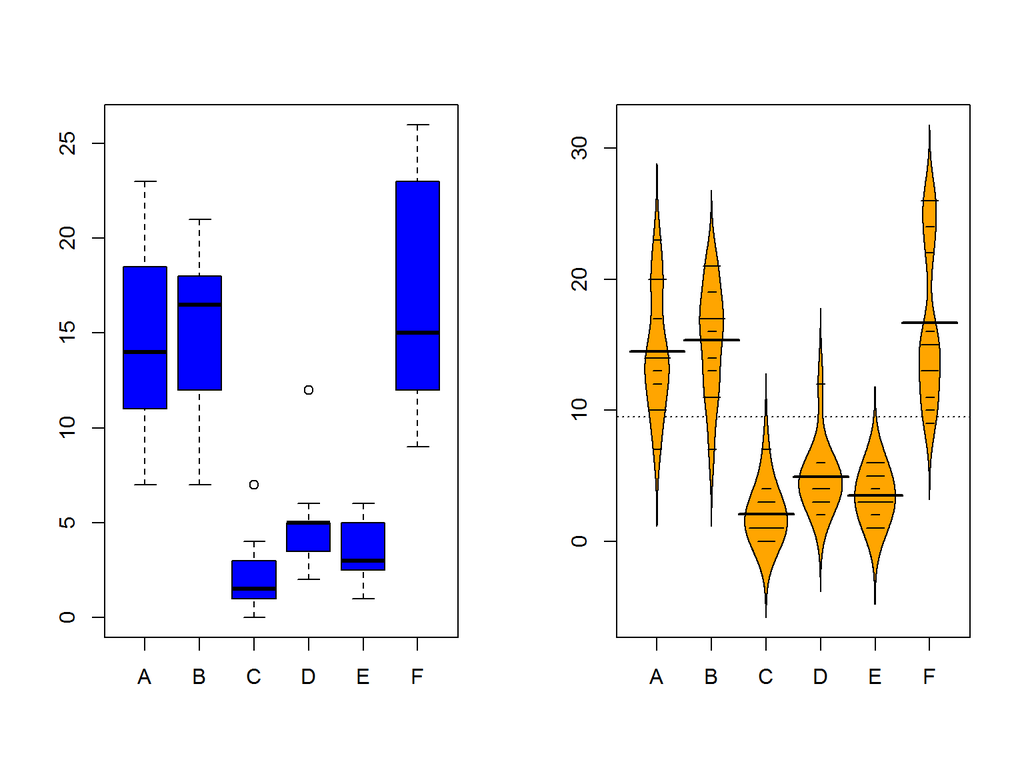

```r
library(beanplot)
par(mfrow = c(1,2))
boxplot(count~spray,data=InsectSprays,col="blue")
beanplot(count~spray,data=InsectSprays,col="orange")
```

# Grafiken fÃ¼r bedingte, bi- und multivariate Verteilungen

# Scatterplots

- Ein einfacher two-way scatterplot kann mit der Funktion plot() erstellt werden
- plot() muss mindestens ein x und ein y Beobachtungsvektor Ã¼bergeben werden
- Um die Farbe der Plot-Symbole anzupassen gibt es die Option col (Farbe als character oder numerisch)
- Die Plot-Symbole selbst kÃ¶nnen mit pch} (plotting character) angepasst werden (character oder numerisch)
- Die Achenbeschriftungen (labels) werden mit xlab und ylab definiert